# The Effects of Climate Change on the Breeding Success and Timing of African White-backed Vultures

Author

Mieke Deyzel

**Introduction**

Climate change and weather variability

Climate change is widely projected to alter ecological systems by increasing the variability in weather patterns and the occurrence of extreme events across the globe. Events such as severe droughts, heat stress and flooding are predicted to become more frequent, leading to significant pressure on ecological systems. Many studies on the effects of climate change on environmental systems focus on shifts in mean climatic conditions, such as long-term change in precipitation, with less attention given to how increased variability may be driving ecological disruptions (Thornton *et al.* 2014). Although this emphasis has improved the understanding of mean climate trends, evidence suggests that interannual variation in climatic conditions plays a crucial role in the ecological response (Maxwell *et al.* 2018). Annual fluctuations in climatic conditions increase the unpredictability of environmental responses and often result in some years being more favourable than others, influencing the availability of important resources such as food, which can cause physiological stress to individuals, populations, and whole ecosystems. This results in substantial variation in the fitness and survival rates of species across multiple years, depending on the environmental conditions (Vázquez *et al.*2015, Berzins *et al.* 2020). Therefore, annual variability in climate is an often-overlooked driver of ecological response to environmental change, emphasising its importance in assessing the impacts of climate change on natural systems.

Effects of climatic variation on avian populations

Studying the consequences of changing weather patterns on avian population biology has become a major field of study over the years, with BirdLife International identifying extreme weather events as the biggest threat to bird populations (Jenouvier 2013). Additionally, predicting the way in which bird populations respond to future climatic changes is of high demand to implement the most effective conservation strategies to mitigate any harmful consequences of climate change (Jenouvier 2013). It has been noted that weather conditions can alter metabolic rates, changes in adult bird body size, and influence the conditions during important activities, such as foraging and courtship, thereby affecting success (Crick 2004). Additionally, weather has an impact on the reproductive success and reproductive phenology of avian populations.

Weather influences avian breeding success

The reproductive success of many organisms relies on numerous factors, including food availability, environmental conditions, population dynamics, and, importantly, their response to shifting climatic conditions. Consequently, this led to several studies focusing on how climate change is affecting important reproductive parameters, including reproductive success, timing of reproduction and clutch size, with significant effects found across multiple species (Nielsen and Møller 2006).

Conditions such as severe droughts, flooding, heat or cooling events reduce the survival rate and typically result in failed reproduction. In avian populations specifically, precipitation and temperature are known to affect the reproductive success of adult birds and the overall condition of the nestlings (Griebel and Dawson 2019). A study conducted by Dawson and Bortolotti (2000) on the reproductive success of Kestrels found that in the event of inclement weather had significant effects on reproductive success, as nestlings were smaller in size and body mass, making a successful fledgling less probable compared to nestlings during more favourable conditions. The decreased probability of producing a fledgling could be due to either direct or indirect effects. The direct effects include extensive energy expenditure on thermoregulation during cooling events, causing significant chilling of the chicks, and indirect effects include reduced hunting effort and prey delivery to the nest by parent birds (Dawson and Bortolotti 2000). Additionally, significant impacts of inclement weather are seen over periods as short as 3 days, leading to either partial or complete brood failure and decreased fledging success (Dawson and Bortolotti 2000).

Vultures

Across the globe, there are 23 vulture species, most of them within the family Accipitridae and the remaining species within the family Cathartidae, and while some species are range restricted, a large number of these species are found across multiple continents (Ogada *et al.* 2012). Vultures are considered to play a vital role in maintaining the health of entire ecosystems through their role as specialised terrestrial scavengers and recycling large amounts of organic waste within an ecosystem (Carucci *et al.* 2022). Vultures can swiftly locate and consume carrion, and by doing so, they create competition for and control other often problematic scavenger populations such as jackals and rodents (Buechley and Sekercioglu 2016). Through their quick disposal of carrion, which acts as a reservoir for harmful diseases, including rabies and anthrax, vultures limit the spread of these pathogens into the ecosystem (Ogada *et al.* 2012). Thus, the absence of vultures, or a large decline in vulture populations, could have significant consequences on the health and, therefore, overall productivity of ecosystems.

Despite their ecological importance, vultures are considered one of the most threatened avian groups across the globe, with rapid declines in populations documented for most of the species (Overveld *et al.* 2020). Threats to vulture populations include pesticide and lead poisoning, powerline collision, habitat loss, and disturbances during breeding, such as limited food availability and increased sporadic weather events (Ives *et al.* 2022). Vultures are large-bodied birds, known for high flight speed, increased foraging ranges and the important ability to store energy reserves in the event of scarce food availability (Ogada *et al.* 2012). In addition, vultures are also known for their slow life history strategy, focusing on long-term survival, growth, parental investment and include delayed maturity and low reproductive rates (Perrig *et al.* 2019). These life-history traits make vultures especially vulnerable to reduced reproductive success, which has long-term consequences for future population stability.

African White-Backed Vultures

The African white backed vulture (*Gyps africanus*) is the most widespread and common vulture species across Africa, and as tree dwellers, these vultures are typically found in wooded savannah and bushfield areas (Mundy *et al.* 1992). White-backed vultures are classified as critically endangered by the IUCN Redlist because of the rapidly declining population (IUCN 2021). Currently, there are approximately 4000 breeding pairs of white-backed vultures, and they typically nest at the top of small to medium-sized scattered woody trees such as camelthorn in southern Africa (Mundy *et al.* 1992). White-backed vultures are monogamous, and during breeding season, one egg is laid typically between April – July. Thereafter, the egg is expected to hatch after roughly 60 days, which is followed by parental care from both parents for about 6 months after the chick has fledged. Depending on the region, the breeding success of white-backed vultures is highly variable, ranging from 40-90%.

Conway *et al.* (2015) predicted that Southern Africa will experience significant shifts in climatic conditions, including increased temperatures and changing rainfall patterns, causing major shifts in climatically suitable habitats for numerous species. In the context of vultures, it has been proposed that climate change could have contributed to the historical loss of Cape vulture colonies, resulting from increased temperatures and shifts in rainfall patterns documented in the region (Phipps *et al.* 2017). Cape vultures nest at high elevations, typically on the edges of cliffs, making them and their nests sensitive to weather extremes such as prolonged periods of sun exposure that cause heat stress, decreasing the overall breeding success of the colonies (Phipps *et al.* 2017).

To be added somewhere Reductions in breeding success, reproductive investments, or missed breeding seasons, driven by weather fluctuations, often lead to population declines, especially in long-lived species where recruitment depends on the repetition of successful breeding seasons (Andreasson *et al.* 2020) Similar to other large-bodied birds, vultures rely on atmospheric thermals for efficient soaring to locate food, which could become constrained when there is an increase in rainfall that suppresses the formation of these thermals (Virani *et al.* 2012). Constraints like these could cause vultures to reduce their breeding activity and therefore alter their population dynamics because food availability is one of the most important factors that cause variation in the reproductive success of avian species, as they often time their breeding to correspond with high food availability (Harriman *et al.* 2017). These effects are typically seen in years that are known for prolonged rainfall events, and the lasting effects of reduced foraging efficiency are reflected throughout the breeding season.  
Warmer years are noted to have earlier egg laying dates as most bird species aim to correspond laying dates with periods of high food availability (Andreasson *et al.* 2020).

## Aims and Objectives

By analysing 31 years of breeding phenology data alongside local weather data, this project aims to determine if, and how, weather affects the reproductive timing and success of African White Backed Vultures. To address this, three main objectives were identified:

1. To assess whether annual weather variation is associated with varying breeding effort of African white-backed vultures, measured in the total number of nests per year.

We hypothesise that the breeding effort of white-backed vultures will be reduced in years with inclement weather conditions characterised by higher annual temperatures and wind, prolonged rainfall and increased storm events.

2. To assess whether annual weather variation is associated with varying annual breeding success in white-backed vultures, measured in the proportion of active nests that produce a fledgling.

We hypothesise that the breeding success of white-backed vultures will decrease in years of inclement weather conditions characterised by higher annual temperatures and wind, prolonged rainfall and increased storm events, due to lower reproductive investment.

3. To assess whether annual weather conditions in the pre-laying period are associated with the breeding timing of white-backed vultures.

We hypothesise that the breeding timing, measured in laying dates, is influenced by the weather conditions in the 60 days prior to laying periods, which reflects white-backed vulture sensitivity to environmental cues before breeding.

**Methods (Still need to add DAGs)**

**Study Area**

The breeding data used in this study were collected at Dronfield Nature Reserve, approximately 5km north of Kimberley in the Northern Cape, South Africa. Dronfield is part of a greater portion of protected and farming landscape, allowing vultures to regularly move between breeding and foraging areas. Dronfield is located within a semi-arid region with a dominant vegetation type, the Kimberley Thornveld and has a mean annual rainfall of approximately 400 mm. The Thornveld is known for its open savanna structure with camel thorn trees scattered across the landscape with tall grasses in between. In addition, Dronfield includes numerous areas of semi-open mixed woodland, which, in combination with the savanna structure, supports a long-term breeding population of White-backed Vultures (Gyps africanus). The nests of more than 100 White-backed vulture breeding pairs are mainly found within medium to large camel thorn trees found across the reserve. This breeding colony is one of six in the greater Kimberley area, with few relatively few threats while under Dronfield management. However, the threat of powerline electrocution is persistent as multiple powerlines run across the reserve. Additionally, when these vultures leave the reserve, they are faced with numerous surrounding threats, such as food shortage due to land use change, poisoning, such as lead poisoning associated with hunting activities and drowning in surrounding farmland areas while foraging. The consistent distribution of suitable nesting habitats at Dronfield resulted in a consistent spatial distribution of nest sites across the years, allowing for repeated long-term monitoring of the individual nest sites.

**Data collection**

The long-term monitoring program of African White-backed vultures commenced in 1993, with few methodical adjustments made to date. The primary goal of the monitoring program has been to document the population dynamics and breeding activity of the African White-backed vulture population in the reserve, with a specific focus on breeding success and effort across the years. These surveys were conducted by experienced observers, each ensuring standarised protocols for nest identification, assessment, and recording of breeding data using the same data sheets.

[output not shown]

**Data Analyses ( to be adjusted and added to)**

(Still need to add DAGs)

We analysed the relationship between annual weather variation and the breeding performance of African White Backed Vultures using the long-term data collected at Dronfield. Moreover, we examined how the weather affects three main aspects of the reproductive cycle, including breeding effort (number of active nests), breeding success (proportion of nests that produced a fledgling) and breeding timing (assessed using estimated laying dates). All statistical analyses were conducted in R statistical computing environment (R version 4.4.1).

Weather data

The weather variables used in this study were derived from a package in the program R 4.4.1, rnoaa, by specifying the weather station ID most suitable for our data (Posit Team 2025). The weather variables were derived from Kimberley meteorological station, 10 km from our study area, Dronfield. The variables used in the analyses were selected to represent a broad understanding of the climatic variation experienced at Dronfield and were biologically motivated. To broadly classify the variables, rainfall, temperature and extreme events were assessed for their impacts on the three outlined focus areas of the breeding cycle. Using the daily weather summaries derived from the weather station, annual and seasonal summaries were used to generate the weather predictors used in the analysis.

The objectives were analysed separately by using specific statistical models deemed fit for the structure of the response variable. This was done by adopting a candidate model set approach for each objective, where the different models represented a biologically motivated hypothesis of how the selected predictor variables might affect each stage of the breeding cycle. Therefore, each model was representative of an explanation for the observed variation in breeding effort, breeding success and timing.

A model selection approach was used, which involved fitting the set of priori models and then calculating the sample size-adjusted Akaike’s Information Criterion (AICc) for each one. Models that have smaller AICc values were considered as stronger support models. The candidate models were then ranked by the difference in their AICc values (∆AICc) relative to the best supported model for each objective to identify which weather predictor, or combinations of predictors, better explained variation in each breeding response.

Because of the continuous nature of both breeding timing and breeding effort, these two objectives were analysed using linear regression models. Breeding effort, measured as the number of active nests in each breeding season, was log-transformed before conducting the analyses to adhere to model assumptions, whereas breeding timing was deemed normally distributed before fitting the model. The breeding success objective was analysed using binomial models using a logit link function, as breeding success is measured as the proportion of successful nests relative to the total number of nests each breeding season. By using the proportion of successful nests, it accounted for the variation in sample sizes across the multiple breeding seasons.

Due to the temporal structure of the data, year was added to the analyses to account for the unmeasured annual variation that is not directly attributed to weather conditions. For breeding effort, models were fitted with and without year as a covariate to compare models and determine the effects of weather conditions with and without accounting for the temporal trend. In the breeding success models, year was added to the models as a random effect to account for the unmeasured annual variation in the baseline breeding success, while the fixed effects of weather were modelled. The main focus of the breeding timing was to identify the effects of weather during the pre-laying window and which variables acted as a cue to initiate breeding, therefore year was not included in these models as a predictor variable. To assess the effects of weather on the pre-laying period, weather variables were summarised for the 30 and 60 days before the laying date and fitted to the models. The laying date was only available for the successful nests, as the unsuccessful nests lacked the information needed to estimate laying date

**Results**

*Objective 1: Breeding effort*

The breeding effort, quantified as the annual number of active nests, shows clear fluctuations across the years, however, the long-term increase in breeding effort remains evident (Figure 1).

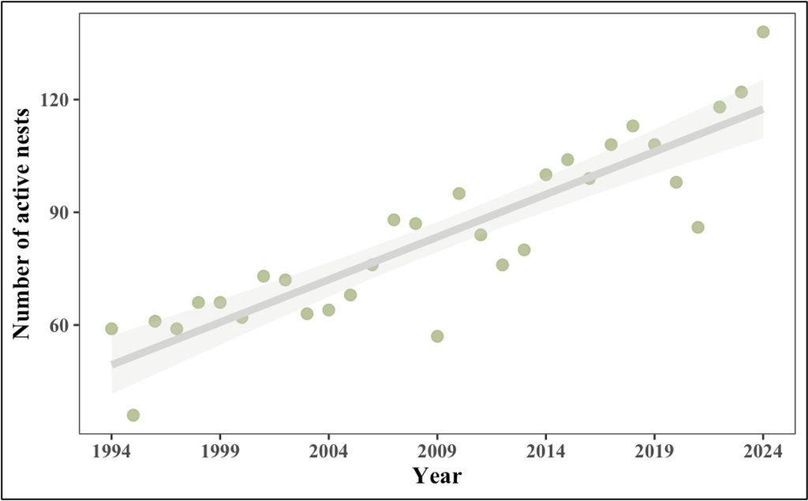

Figure 1: The breeding effort, represented as the number of active nests each breeding season, across the study period.

The strong temporal signal observed in Figure 1 was reflected in the model selection results (Table 1). Year accounted for the majority of the variation in the breeding effort, with the selected weather variables accounting for minimal additional explanatory power.

**Table 1:** The model selection results relating to the annual weather variation to breeding effort, measured in the number of active nests at Dronfield between 1993 and 2024. Models were fitted using linear regressions. A ‘+’ between two predictor weather variables indicates additive effects, and ‘x’ indicates an interaction term. The number of parameters is represented by K, with AICc being Akaike’s Information Criterion. ∆AICc represents the difference in AICc compared to the best supporting model, and w represents the Akaike weight. Adjusted R2 represents the proportion of variance explained by each model. Regression coefficients (slope) with standard error are reported for the simple predictor models only.

| Model | K | AICc | ΔAICc | w | Adj. R² | slope (SE) |
| --- | --- | --- | --- | --- | --- | --- |
| **Baseline** |  |  |  |  |  |  |
| Year (baseline) | 3 | -28.43 | 0.64 | 0.140 | 0.759 |  |
| **Rain** |  |  |  |  |  |  |
| Maximum daily rainfall | 4 | -29.07 | 0.00 | 0.193 | 0.775 | -0.002 (0.001) |
| Total rainfall | 4 | -27.49 | 1.58 | 0.088 | 0.764 | 0 (0) |
| Previous year’s total rainfall | 4 | -25.81 | 3.27 | 0.038 | 0.751 | 0 (0) |
| Rainy days | 4 | -25.78 | 3.29 | 0.037 | 0.750 | 0 (0.002) |
| **Temperature** |  |  |  |  |  |  |
| Minimum temperature | 4 | -26.68 | 2.39 | 0.058 | 0.757 | 0.016 (0.017) |
| Mean temperature | 4 | -26.59 | 2.48 | 0.056 | 0.757 | 0.026 (0.030) |
| Maximum temperature | 4 | -26.42 | 2.65 | 0.051 | 0.755 | 0.010 (0.013) |
| **Wind** |  |  |  |  |  |  |
| Maximum wind speed | 4 | -25.90 | 3.18 | 0.039 | 0.751 | -0.002 (0.006) |
| Mean wind speed | 4 | -25.87 | 3.21 | 0.039 | 0.751 | -0.019 (0.070) |
| **Hail** |  |  |  |  |  |  |
| Hail days | 4 | -25.88 | 3.19 | 0.039 | 0.751 | 0.006 (0.020) |
| **Joint effects** |  |  |  |  |  |  |
| Min temperature + max daily rainfall | 5 | -27.44 | 1.63 | 0.085 | 0.776 |  |
| Max daily rainfall + max wind speed | 5 | -26.41 | 2.66 | 0.051 | 0.769 |  |
| Min temperature + total rainfall | 5 | -25.04 | 4.03 | 0.026 | 0.758 |  |
| Min temperature + max wind speed | 5 | -23.83 | 5.24 | 0.014 | 0.749 |  |
| Max temperature + rainy days | 5 | -23.78 | 5.29 | 0.014 | 0.748 |  |
| Hail days + max wind speed | 5 | -23.12 | 5.95 | 0.010 | 0.743 |  |
| Hail days + rainy days | 5 | -23.03 | 6.04 | 0.009 | 0.742 |  |
| **Interactions** |  |  |  |  |  |  |
| Prev. rainfall × max temperature | 6 | -21.36 | 7.71 | 0.004 | 0.744 |  |
| Min temperature × mean wind speed | 6 | -21.30 | 7.77 | 0.004 | 0.744 |  |
| Min temperature × rainy days | 6 | -21.04 | 8.03 | 0.003 | 0.741 |  |

The model selection indicated that breeding effort was weakly associated with the weather predictors. The model best supported was the maximum daily rainfall (∆AICc = 0.00, w = 0.19), however, the effect remains small (slope = -0.002). The baseline model that included only year showed similar support compared to the top-supported model (∆AICc = 0.64, w = 0.14). The number of rain days and the lagged rainfall (based on the previous year’s rainfall) showed limited support (∆AICc > 2). Models that included temperature predictors indicated moderate support, with all predictor variables ranging within ∆AICc = 2.3 and 2.7. Single models, including wind and hail, showed poor performance. Neither the interaction effect nor the additive models improved the model fit compared to single predictor models, with interactive models showing poor received little support (∆AICc > 7).

*Objective 2: Breeding success*

**Table 2**: The model selection results relating to annual weather variation to breeding success, quantified as the number of successful nests relative to unsuccessful nests. Models were fitted using a binomial generalised linear mixed- effects model. A ‘+’ between two predictor weather variables indicates additive effects, and ‘x’ indicates an interaction term. The number of parameters is represented by K, with AICc being Akaike’s Information Criterion. ∆AICc represents the difference in AICc compared to the best supporting model, and w represents the Akaike weight. Deviance explained is comparable to R2. Regression coefficients (slope) with standard error are reported for the simple predictor models only.

| Model | K | AICc | ΔAICc | w | Deviance explained | slope (SE) |
| --- | --- | --- | --- | --- | --- | --- |
| **Baseline** |  |  |  |  |  |  |
| Intercept only | 2 | 229.45 | 2.52 | 0.123 | 0.000 |  |
| **Temperature** |  |  |  |  |  |  |
| Minimum temperature | 3 | 226.93 | 0.00 | 0.435 | 0.210 | 0.167 (0.072) |
| Maximum temperature | 3 | 230.85 | 3.92 | 0.061 | 0.042 | -0.077 (0.075) |
| **Rain** |  |  |  |  |  |  |
| Maximum daily rainfall | 3 | 231.01 | 4.09 | 0.056 | 0.034 | 0.075 (0.079) |
| Rainy days | 3 | 231.61 | 4.68 | 0.042 | 0.014 | -0.041 (0.076) |
| Total rainfall | 3 | 231.65 | 4.72 | 0.041 | 0.008 | 0.038 (0.076) |
| **Wind** |  |  |  |  |  |  |
| Maximum wind speed | 3 | 231.73 | 4.81 | 0.039 | 0.003 | -0.031 (0.077) |
| **Hail** |  |  |  |  |  |  |
| Hail days | 3 | 230.45 | 3.53 | 0.074 | 0.052 | -0.088 (0.073) |
| **Joint effects** |  |  |  |  |  |  |
| Max temperature + rainy days | 4 | 232.10 | 5.18 | 0.033 | 0.104 |  |
| Rainy days + hail days | 4 | 232.30 | 5.38 | 0.030 | 0.087 |  |
| Hail days + max wind speed | 4 | 232.67 | 5.74 | 0.025 | 0.062 |  |
| **Interactions** |  |  |  |  |  |  |
| Min temperature × wind speed | 5 | 232.04 | 5.11 | 0.034 | 0.225 |  |
| Max temperature × rainy days | 5 | 234.93 | 8.01 | 0.008 | 0.104 |  |

The model selection indicated that the breeding success had clearer associations with the weather variables included in the models (Table 2). The model showing the best support (∆AICc = 0.00, w = 0.44) is the single predictor model including minimum temperature, explaining the largest proportion of deviance compared to any of the other models (21%). The other models with single predictor variables explained little extra deviance and weak support relative to the best supported model (∆AICc > 3). The same was seen for models that had additive and interactive predictor variables, showing weak support compared to the best-supported model.

Figure 2, showing the relationship between the predictor variable, minimum temperature and breeding success, indicates a positive relationship (slope = 0.167). Years with warmer temperatures have higher breeding success, as the upward trend suggests (Figure 2). The graphs also indicate that the observed breeding success varies substantially around the fitted relationship.

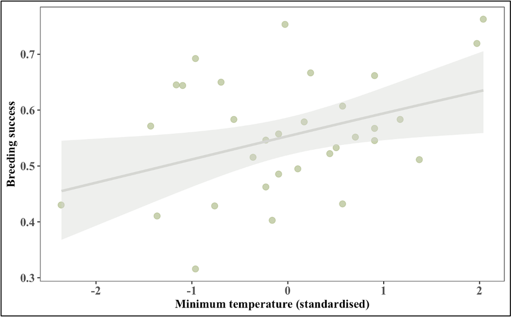

Figure 2: The relationship between minimum temperature and breeding success, expressed as the proportion of successful nests.

**Table 3**: Results from the analyses comparing breeding success models including minimum temperature only, population size, and the combination of both predictor variables. ∆AICc ranks the models with the Akaike weight (w), indicating the relative support of each model. Between-year variance is calculated relative to the null model

| Model | ΔAICc | w | Between-year variance explained |
| --- | --- | --- | --- |
| Minimum temperature | 6.91 | 0.03 | 0.21 |
| Population size | 5.44 | 0.06 | 0.24 |
| Minimum temperature + population size | 0.00 | 0.91 | 0.50 |

*Objective 3: Breeding timing*

**Table 4:** Results from the model selection relating breeding timing, predicted by laying date, and the 30 day pre-laying weather conditions at Dronfield. Models were fitted using linear regressions. A ‘+’ between two predictor weather variables indicates additive effects, and ‘x’ indicates an interaction term. The number of parameters is represented by K, with AICc being Akaike’s Information Criterion. ∆AICc represents the difference in AICc compared to the best supporting model, and w represents the Akaike weight. Adjusted R2 represents the proportion of variance explained by each model. Regression coefficients (slope) with standard error are reported for the simple predictor models only.

| Model | Deviance | K | AICc | ΔAICc | w | R² | Slope (SE) |
| --- | --- | --- | --- | --- | --- | --- | --- |
| **Temperature** |  |  |  |  |  |  |  |
| Minimum temperature | 230,069.4 | 2 | 11,529.94 | 193.94 | 0.000 | 0.499 | -5.010 (0.131) |
| Mean temperature | 241,441.3 | 2 | 11,600.33 | 264.33 | 0.000 | 0.475 | -5.478 (0.151) |
| Maximum temperature | 280,751.2 | 2 | 11,820.41 | 484.41 | 0.000 | 0.389 | -4.775 (0.157) |
| **Rain** |  |  |  |  |  |  |  |
| Rainy days | 404,580.3 | 2 | 12,360.96 | 1,024.96 | 0.000 | 0.161 | -2.103 (0.126) |
| Total rainfall | 415,698.5 | 2 | 12,400.54 | 1,064.54 | 0.000 | 0.138 | -0.286 (0.019) |
| **Wind** |  |  |  |  |  |  |  |
| Maximum wind speed | 449,433.4 | 2 | 12,506.89 | 1,170.89 | 0.000 | 0.022 | 4.154 (0.727) |
| Mean wind speed | 452,345.2 | 2 | 12,516.32 | 1,180.31 | 0.000 | 0.016 | 4.397 (0.915) |
| **Lagged effects** |  |  |  |  |  |  |  |
| Previous year’s total rainfall | 444,303.8 | 2 | 12,278.29 | 942.29 | 0.000 | 0.010 | 0.013 (0.003) |
| Previous year’s rainy days | 447,834.4 | 2 | 12,289.62 | 953.61 | 0.000 | 0.003 | 0.062 (0.032) |
| Previous year’s mean temperature | 448,801.1 | 2 | 12,292.70 | 956.70 | 0.000 | 0.000 | -0.456 (0.576) |
| **Joint effects** |  |  |  |  |  |  |  |
| Mean temperature + rainy days | 203,046.6 | 3 | 11,349.65 | 13.65 | 0.001 | 0.558 |  |
| Mean temperature + mean wind speed | 236,458.4 | 3 | 11,571.91 | 235.91 | 0.000 | 0.485 |  |
| Rainy days + mean wind speed | 369,830.8 | 3 | 12,224.48 | 888.48 | 0.000 | 0.195 |  |
| **Interactive effects** |  |  |  |  |  |  |  |
| Mean temperature × rainy days | 200,878.1 | 4 | 11,336.00 | 0.00 | 0.999 | 0.563 |  |
| Previous year’s rainfall × mean temperature | 235,450.7 | 4 | 11,373.62 | 37.62 | 0.000 | 0.476 |  |
| Minimum temperature × mean wind speed | 215,499.8 | 4 | 11,438.51 | 102.51 | 0.000 | 0.531 |  |

The breeding timing at Dronfield was best explained by an interaction effect of the mean temperature and the number of rainy days in the 30 day pre-laying period, with this interactive model receiving high support (∆AICc = 0.00, w = 0.999). Additionally, this best supported model accounted for 56.3% of the variation in laying date. The single predictor models showed poor support, showing high ∆AICc values regardless of the explanatory power of the models that included temperature, based on their R2 values (Table 4). Similarly, single predictor models including rainfall also indicated weaker support relative to the best fit model. The previous year’s weather conditions did not indicate a strong influence, and additive explained variance of the current breeding seasons, breeding timing (∆AICc > 900).

**Table 5:** Results from the analyses comparing breeding timing models, including the interactive effects of mean temperature and rainy days, population size, and the combination of both models. ∆AICc ranks the models with the Akaike weight (w), indicating the relative support of each model.

| Model | ΔAICc | w | R² |
| --- | --- | --- | --- |
| Mean temperature × rainy days | 65.56 | 0 | 0.56 |
| Population size | 1,266.51 | 0 | 0.00 |
| Mean temperature × rainy days + population size | 0.00 | 1 | 0.58 |